# Data Translation Project: The Effect of Covid on the Retail Industry

Maxwell Nicely, Liev Haroche, Brian Thomas, Madelyn Subali, Arshdeep Brar, Paul Gano

2022-06-08

## Introduction and Loading Data

In late 2019 concern’s were focused on the coming presidential election rather than a newly announced novel respiratory disease in China. But as we all know, come March 2020, this virus had fundamentally changed life the world over. Our primary interest is it’s effect on the U.S.A retail employees. Specifically the three questions we will be asking are, how has COVID-19 impacted the employment rate in retail, how has the retail industry been impacted compared to other industries, and who is still working and able to spend money.

We will be using regression analysis to estimate the effects caused by the start of COVID-19 in the US (March 2020). As lock downs began partway through March, this analysis will treat the month as the start. We will be limiting our analysis to 2019 through early 2022.

### Loading Data

```r
library(ipumsr)
library(tidyverse)
library(fixest)
library(lubridate)
library(vtable)
library(purrr)
library(multcomp)
library(rdrobust)
```

```r
ddi <- read_ipums_ddi('cps_00001.xml')
data <- read_ipums_micro(ddi)
```

```
## Use of data from IPUMS CPS is subject to conditions including that users should
## cite the data appropriately. Use command `ipums_conditions()` for more details.
```

```r
ddi2 <- read_ipums_ddi('cps_00002.xml')
data2 <- read_ipums_micro(ddi2)
```

```
## Use of data from IPUMS CPS is subject to conditions including that users should
## cite the data appropriately. Use command `ipums_conditions()` for more details.
```

```r
industry_codes <- read_csv('indnames.csv')
```

## Question 1

### How has COVID affected the health of the retail industry, as measured by employment?

### Data Cleaning

Looking at retail employment we limit our data to relevant industry codes and only employees in the labor force.

```r
#filter out industries
Q1data <- data %>% filter(IND > 4670 & IND < 5790)

#filter out not in labor force
Q1data <- Q1data %>% filter(EMPSTAT < 30)
```

To make our future commands easier, we will now create a date value by combining the `YEAR` and `MONTH` values.

```r
Q1data <- Q1data %>% mutate(DATE = ym (paste0(YEAR, MONTH)))
```

Now there are a few date-based variables we have to make, such as a binary variable for months that were during the pandemic versus not, and one for months during Christmas season or not. We will be controlling for the Christmas bump in our regression analysis so It doesn’t make COVIDs effect positivily biased.

```r
#creating covid variable
Q1data <- Q1data %>% mutate(COVID = (DATE > '2020-03-01'))

#creating Christmas variable
Q1data <- Q1data %>% mutate(XMAS = MONTH >= 11)
```

Now we need to create a categorical variable for `RACE`, since the original data gives a numerical value for one’s race. Controlling for race in our regression analysis will show us if there were significant differences in impact.

```r
Q1data$race <- as.factor(ifelse(Q1data$RACE == 100, 'White',
                           ifelse(Q1data$RACE == 200, 'Black',
                           ifelse(Q1data$RACE == 300, 'American Indian/Aleut/Eskimo',
                           ifelse(Q1data$RACE >= 650 & Q1data$RACE <= 652, 'Asian or Pacific Islander',
                           ifelse(Q1data$RACE == 700, 'Other (single race)',
                           ifelse(Q1data$RACE >= 801, 'Two or More',NA)))))))
```

Last, we need to create an unemployment rate variable.

```r
Q1data <- Q1data %>%
  group_by(DATE) %>%
  mutate(UnemploymentRate = mean(EMPSTAT %in% c(20,21,22)))
```

### Visualization

Now that we have created all the variables we need, we can look at a plot of our data.

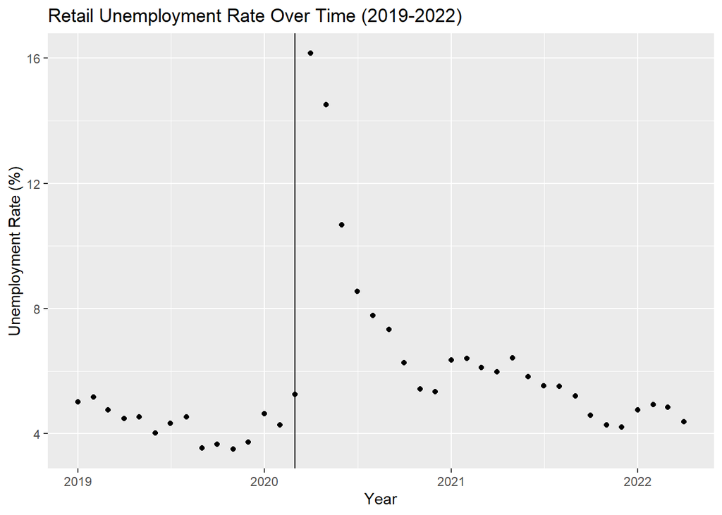

```r
Q1plot <- ggplot(Q1data, aes(DATE, UnemploymentRate*100)) + geom_point() + geom_vline(xintercept = as.numeric(as.Date('2020-03-01')))

Q1plot + ggtitle("Retail Unemployment Rate Over Time (2019-2022)") + xlab('Year') +ylab('Unemployment Rate (%)')
```

As we can see from the graph, there is a sharp increase in the unemployment rate with the largest spike occuring in April. We can also clearly see the Christmas effect with a dip occurring at the end of each year and then sharply increasing in January.

### Regression Models

In our first model we will be controlling for variables we think will effect the employment rate such as Age and Race. We also wanted to eliminate variance due to differenes across time such as the christmas bump.

```r
Q1analysis <- feols(UnemploymentRate ~  DATE + COVID + AGE + race + XMAS, data = Q1data)
etable(Q1analysis)
```

```
##                                       Q1analysis
## Dependent Var.:                 UnemploymentRate
##
## (Intercept)                    1.344*** (0.0033)
## DATE                       -7.17e-5*** (1.79e-7)
## COVIDTRUE                     0.0651*** (0.0001)
## AGE                         1.49e-5*** (1.98e-6)
## raceAsianorPacificIslander      -0.0001 (0.0003)
## raceBlack                       1.25e-5 (0.0003)
## raceTwoorMore                    0.0003 (0.0003)
## raceWhite                        0.0003 (0.0003)
## XMASTRUE                    -0.0113*** (9.43e-5)
## __________________________ _____________________
## S.E. type                                    IID
## Observations                             226,412
## R2                                       0.56540
## Adj. R2                                  0.56539
## ---
## Signif. codes: 0 '***' 0.001 '**' 0.01 '*' 0.05 '.' 0.1 ' ' 1
```

From our regression, the time after covid began (from April 2020 and on in our data) had an increase of 6.51% in the unemployment rate for inidividuals of the same race and age at the same time of year. We also see that Age is significant in unemployment but the coeffcient is so small as to not impact much. And while the race variables are not significant on their own, if we run a joint significance test we will see the p-value is less than an alpha of .05.

```r
wald(Q1analysis, "race")
```

```
## Wald test, H0: joint nullity of raceAsian or Pacific Islander, raceBlack, raceTwo or More and raceWhite
##  stat = 3.05445, p-value = 0.015805, on 4 and 226,403 DoF, VCOV: IID.
```

The next two analysis we wanted to see if COVID-19 had a different effect based on the race and age of individuals. We used interaction terms to see the unit change.

```r
Q1analysis1 <- feols(UnemploymentRate ~ DATE + COVID + AGE + race + XMAS + COVID:race, data = Q1data)
etable(Q1analysis1)
```

```
##                                                  Q1analysis1
## Dependent Var.:                             UnemploymentRate
##
## (Intercept)                                1.344*** (0.0033)
## DATE                                   -7.17e-5*** (1.79e-7)
## COVIDTRUE                                 0.0649*** (0.0006)
## AGE                                     1.49e-5*** (1.98e-6)
## raceAsianorPacificIslander                  7.43e-5 (0.0005)
## raceBlack                                    0.0001 (0.0005)
## raceTwoorMore                                0.0002 (0.0005)
## raceWhite                                   8.42e-5 (0.0004)
## XMASTRUE                                -0.0113*** (9.43e-5)
## COVIDTRUE x raceAsianorPacificIslander      -0.0003 (0.0006)
## COVIDTRUE x raceBlack                       -0.0002 (0.0006)
## COVIDTRUE x raceTwoorMore                    0.0002 (0.0007)
## COVIDTRUE x raceWhite                        0.0003 (0.0006)
## ______________________________________ _____________________
## S.E. type                                                IID
## Observations                                         226,412
## R2                                                   0.56542
## Adj. R2                                              0.56540
## ---
## Signif. codes: 0 '***' 0.001 '**' 0.01 '*' 0.05 '.' 0.1 ' ' 1
```

Similar result from previous one for covid impact. Interesting decrease in unemployment rate from `COVIDTRUE x raceAsianorPAcificIslander` and `COVIDTRUE x raceBlack` while there was a slight increase in `COVIDTRUE x raceTwoorMore` and `COVIDTRUE x raceWhite`.

```r
Q1analysis2 <- feols(UnemploymentRate ~ DATE + race + XMAS + COVID + AGE + COVID:AGE, data = Q1data)
etable(Q1analysis2)
```

```
##                                      Q1analysis2
## Dependent Var.:                 UnemploymentRate
##
## (Intercept)                    1.344*** (0.0033)
## DATE                       -7.17e-5*** (1.79e-7)
## raceAsianorPacificIslander      -0.0001 (0.0003)
## raceBlack                       7.52e-6 (0.0003)
## raceTwoorMore                    0.0003 (0.0003)
## raceWhite                        0.0003 (0.0003)
## XMASTRUE                    -0.0113*** (9.43e-5)
## COVIDTRUE                     0.0644*** (0.0002)
## AGE                           5.21e-6. (3.03e-6)
## COVIDTRUE x AGE             1.68e-5*** (3.98e-6)
## __________________________ _____________________
## S.E. type                                    IID
## Observations                             226,412
## R2                                       0.56544
## Adj. R2                                  0.56542
## ---
## Signif. codes: 0 '***' 0.001 '**' 0.01 '*' 0.05 '.' 0.1 ' ' 1
```

Similar impact from covid as other two. After covid, we see a slight increase in the impact of `AGE` on the unemployment rate.

## Question 2

### How has retail fared relative to other industries?

### Data Cleaning

```r
Q2data <- mutate(data2, Date=ym (paste0(YEAR, MONTH)))
Q2data <- inner_join(Q2data, industry_codes, by=c('IND' = 'ind'))
Q2data <- mutate(Q2data, treated=(Date > '2020-03-01'))
Q2data <- Q2data %>% mutate(unemployed = (EMPSTAT %in% c(20, 21, 22)))
Q2data <- mutate(Q2data, retail=indname=='Retail Trade')
Q2data <- Q2data %>% group_by(indname=='Retail Trade', Date) %>%
  mutate(unemployment_rate=mean(unemployed))
```

Joining up data to industry names so we can filter between retail and other industries.

### Visulization

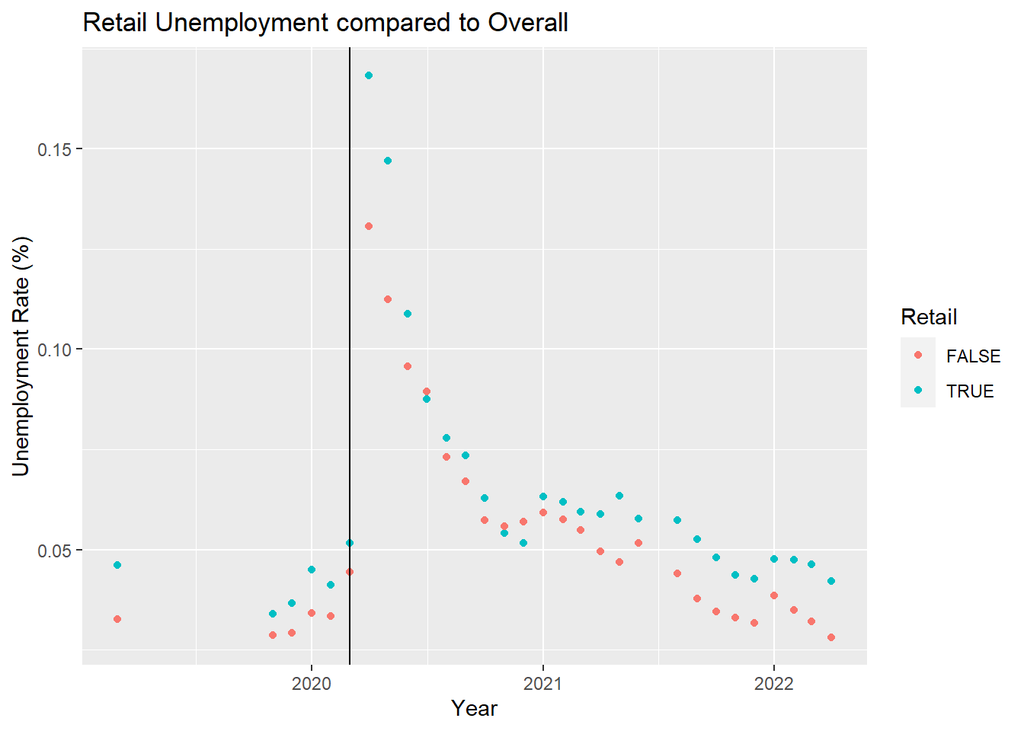

```r
ggplot(group_by(Q2data, retail), aes(x=Date, y=unemployment_rate)) + geom_point(aes(color=factor(retail))) + geom_vline(xintercept = as.numeric(as.Date('2020-03-01'))) + labs(title ="Retail Unemployment compared to Overall", x ="Year", y = "Unemployment Rate (%)", color = "Retail")
```

### Regressions Models

```r
Q2analysis1 <- feols(Q2data, unemployment_rate~treated + retail + treated*retail)
etable(Q2analysis1)
```

```
##                                  Q2analysis1
## Dependent Var.:            unemployment_rate
##
## (Intercept)              0.0353*** (3.43e-5)
## treatedTRUE              0.0213*** (3.98e-5)
## retailTRUE                0.0087*** (0.0001)
## treatedTRUE x retailTRUE  0.0009*** (0.0001)
## ________________________ ___________________
## S.E. type                                IID
## Observations                       1,749,803
## R2                                   0.16761
## Adj. R2                              0.16761
## ---
## Signif. codes: 0 '***' 0.001 '**' 0.01 '*' 0.05 '.' 0.1 ' ' 1
```

```r
Q2data2 <- mutate(Q2data, treated=(Date > '2020-03-01' & Date < '2020-06-01'))
Q2analysis2 <- feols(Q2data2, unemployment_rate~treated + retail + treated*retail)
etable(Q2analysis2)
```

```
##                                  Q2analysis2
## Dependent Var.:            unemployment_rate
##
## (Intercept)               0.0470*** (1.3e-5)
## treatedTRUE              0.0746*** (5.56e-5)
## retailTRUE               0.0080*** (3.99e-5)
## treatedTRUE x retailTRUE  0.0282*** (0.0002)
## ________________________ ___________________
## S.E. type                                IID
## Observations                       1,749,803
## R2                                   0.56314
## Adj. R2                              0.56314
## ---
## Signif. codes: 0 '***' 0.001 '**' 0.01 '*' 0.05 '.' 0.1 ' ' 1
```

For the immediate months after COVID-19 retail industries had a 2.8% higher unemployment rate than other industries.

```r
Q2data3 <- filter(Q2data2, indname %in% c('Retail Trade', 'Information', 'Educational Services, and Health Care and Social Assistance', 'Finance and Insurance, and Real Estate and Rental and Leasing'))
Q2analysis3 <- feols(Q2data3, unemployment_rate~retail + treated + treated*retail)
etable(Q2analysis3)
```

```
##                                  Q2analysis3
## Dependent Var.:            unemployment_rate
##
## (Intercept)              0.0470*** (2.15e-5)
## retailTRUE                0.0080*** (4.3e-5)
## treatedTRUE              0.0746*** (9.16e-5)
## retailTRUE x treatedTRUE  0.0282*** (0.0002)
## ________________________ ___________________
## S.E. type                                IID
## Observations                         735,116
## R2                                   0.60379
## Adj. R2                              0.60379
## ---
## Signif. codes: 0 '***' 0.001 '**' 0.01 '*' 0.05 '.' 0.1 ' ' 1
```

These results do not alter the previous findings. The difference in the effect of COVID on unemployment in the retail industry does not appear to differ from selected industries above as compared to all “non-retail” industries used before.

## Question 3

### What has changed about who is working and earning money?

### Data Cleaning

```r
cleandt <- data2 %>% dplyr :: select(YEAR, MONTH, EMPSTAT, OCC, IND, UHRSWORK1, WKSTAT)
cleandt <- cleandt %>% drop_na()
cleandt <- cleandt %>% mutate(HRSMAIN = UHRSWORK1)
# We filter for Employment Status at 10 (employed) and 20:22 (unemployed)
cleandt <- cleandt %>% filter(EMPSTAT %in% c(10,20:22))
# Denotes for the different months in the years of 2019 to 2022
cleandt <- cleandt %>% mutate(date = ym(paste(YEAR,MONTH)))

# Join the Industry names and cleandt to align broader Industries
cleandt <- cleandt %>% rename(ind = IND)
finaldt <- full_join(cleandt, industry_codes)
# Using binary variables where the industry of 'Retail Trade' will be 1, and others will be 0.
finaldt$industry <- ifelse(finaldt$indname == 'Retail Trade', 1, 0)
emp_rate_by_month <- finaldt %>%
  group_by(industry, date) %>%
  summarize(emp_rate = 1 - mean(EMPSTAT %in% 20:22))
emp_rate_by_month <- emp_rate_by_month %>%
  drop_na(industry) %>%
  drop_na(date)
```

### Visualization

Visualize the difference in the court of employed and unemployed people between those of the different industries. Since we want to see the impact of retail, we will group ‘Others’ as non-retail industries. The cutoff will be March 2020, when the COVID-19 happen.

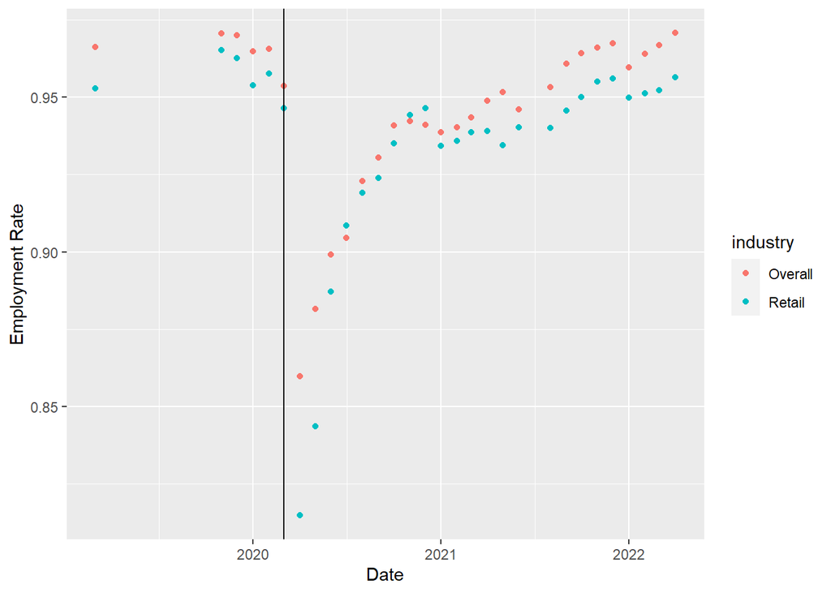

```r
emp_rate_by_month <- emp_rate_by_month %>% mutate(industry= as.factor(industry))

levels(emp_rate_by_month$industry) <- list("Overall" = "0",
                                          "Retail" = "1")
emp_rate_by_month %>% ggplot(aes(x = date, y = emp_rate, color = industry)) + geom_point() + labs(Title = "COVID-19 Impact on Retail Employment compared to Overall",y = "Employment Rate", x = "Date") +
  geom_vline(xintercept = as.Date("2020-03-01"))
```

Here we see that there is a steep decrease in employment rate when COVID-19 happen in March 2020, that causes a drop in employment. It seems like in Retail industry, it is actually doing worse compared to the other industry as we see the average on employment rate after COVID-19 hits is around 0.86, whereas retail industry’s employment rate drops as far as to 0.81.

```r
# Creating bins of the Emp_Rate_By_Month
bindata <- emp_rate_by_month  %>% mutate(emp_bins = cut(emp_rate, breaks = 36))
```

Below is the graph to show the distribution of employment rate. Using March 2020 as the cutoff, the *xintercept = ‘(0.952,0.955]’*. As of before COVID-19, we see that there is a stagnant or relatively flat distribution on the employment rate (count). And even after COVID-19, the data does not show discontinuity in the distribution where we see a huge jump. Thus, the employment rate variables are not manipulated - where some people may not report their employment status.

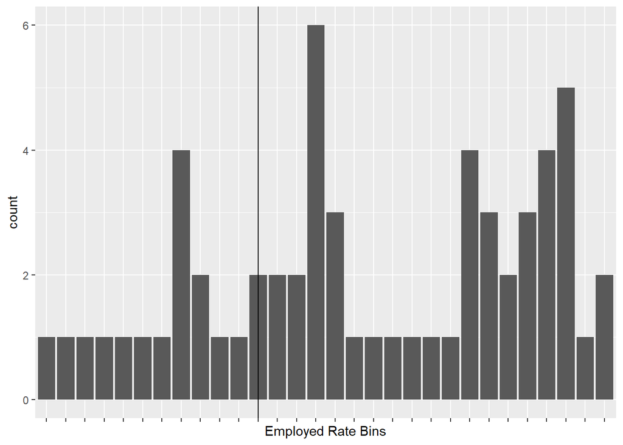

### Regression Models

This will help select a window and weighting kernel to weight observations more near the cutoff. This is done by mutating two new variables called *pre-COVID* and *post-COVID* to access the effect of COVID on employment rate.

```r
treatment <- bindata %>% mutate(precovid = date < as.Date("2020-03-01"), postcovid = date > as.Date("2020-03-01"))

#use feols to look at a regression model to explain the difference
precovid <- feols(emp_rate ~ precovid, data = treatment)

postcovid <- feols(emp_rate ~ postcovid, data = treatment)
etable(precovid, postcovid, vcov = 'hetero')
```

```
##                           precovid           postcovid
## Dependent Var.:           emp_rate            emp_rate
##
## (Intercept)     0.9353*** (0.0045)  0.9608*** (0.0022)
## precovidTRUE    0.0276*** (0.0049)
## postcovidTRUE                      -0.0261*** (0.0051)
## _______________ __________________ ___________________
## S.E. type       Heteroskedas.-rob. Heteroskedast.-rob.
## Observations                    60                  60
## R2                         0.11477             0.11786
## Adj. R2                    0.09951             0.10265
## ---
## Signif. codes: 0 '***' 0.001 '**' 0.01 '*' 0.05 '.' 0.1 ' ' 1
```

In *precovid*, we are looking at the impact of before COVID-19 happen which is before March 2020, where we see an increase in employment rate by 2.7%.

In *postcovid*, we are looking at how the overall impact of COVID-19 on employment rate. After March 2020, we see there is a decrease in employment rate by 2.6%.

Now we want to look at the effect COVID-19 had on employment rate during when vaccines did not exist and how the employment rate improves since the launch of vaccines.

```r
novaccinestreat <- treatment %>% filter(date < as.Date("2021-01-01"))
covidnovaccines <- feols(emp_rate ~ postcovid, data = novaccinestreat)

treatment <- treatment %>% mutate(postvaccines = date > as.Date("2021-01-01"))
postvaccines <- feols(emp_rate ~ postvaccines, data = treatment)
etable(covidnovaccines, postvaccines)
```

```
##                      covidnovaccines       postvaccines
## Dependent Var.:             emp_rate           emp_rate
##
## (Intercept)       0.9608*** (0.0086) 0.9296*** (0.0051)
## postcovidTRUE    -0.0527*** (0.0111)
## postvaccinesTRUE                      0.0221** (0.0075)
## ________________ ___________________ __________________
## S.E. type                        IID                IID
## Observations                      30                 60
## R2                           0.44449            0.13173
## Adj. R2                      0.42465            0.11676
## ---
## Signif. codes: 0 '***' 0.001 '**' 0.01 '*' 0.05 '.' 0.1 ' ' 1
```

In *novaccinestreat*, we are looking between when COVID-19 happen and before the vaccination was released, to see the impact of COVID-19 employment which has a 5% decrease.

In *postvacciness*, we see that there is an overall positive increase in terms of employment rate after vaccination was released on early 2021, thus an increase by 2.2% on employment rate.

Now we want to look further at whether or not non-retail industries took a harder hit from COVID and benefited from vaccines.

```r
novaccinesind <- feols(emp_rate ~ postcovid*industry, data = novaccinestreat)

postvaccinesind <- feols(emp_rate ~ postvaccines*industry, data = treatment)
etable(novaccinesind, postvaccinesind)
```

```
##                                        novaccinesind    postvaccinesind
## Dependent Var.:                             emp_rate           emp_rate
##
## (Intercept)                       0.9652*** (0.0125) 0.9345*** (0.0072)
## postcovidTRUE                     -0.0516** (0.0161)
## industryRetail                      -0.0088 (0.0176)   -0.0098 (0.0102)
## postcovidTRUE x industryRetail      -0.0023 (0.0228)
## postvaccinesTRUE                                       0.0229* (0.0105)
## postvaccinesTRUE x industryRetail                      -0.0015 (0.0149)
## _________________________________ __________________ __________________
## S.E. type                                        IID                IID
## Observations                                      30                 60
## R2                                           0.46197            0.16177
## Adj. R2                                      0.39988            0.11686
## ---
## Signif. codes: 0 '***' 0.001 '**' 0.01 '*' 0.05 '.' 0.1 ' ' 1
```

### Visualization 2

Taking a look at the visualization again with linear lines explaining the effect. We see that from the graph below, the employment rate is stagnant throughout the year before March 2020. As of after March 2020, we see that employment rate for both Retail and non-retail industry keeps on increasing throughout the year.

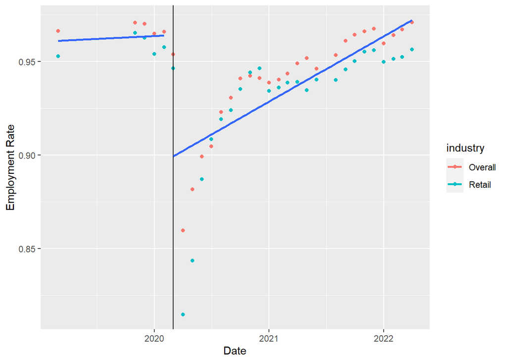

```r
treatment %>% ggplot(aes(x = date, y = emp_rate, color = industry)) + geom_point() + labs(y = "Employment Rate", x = "Date") +
  geom_vline(xintercept = as.Date('2020-03-01')) + geom_smooth(aes(group = precovid), method = 'lm', se = FALSE)
```

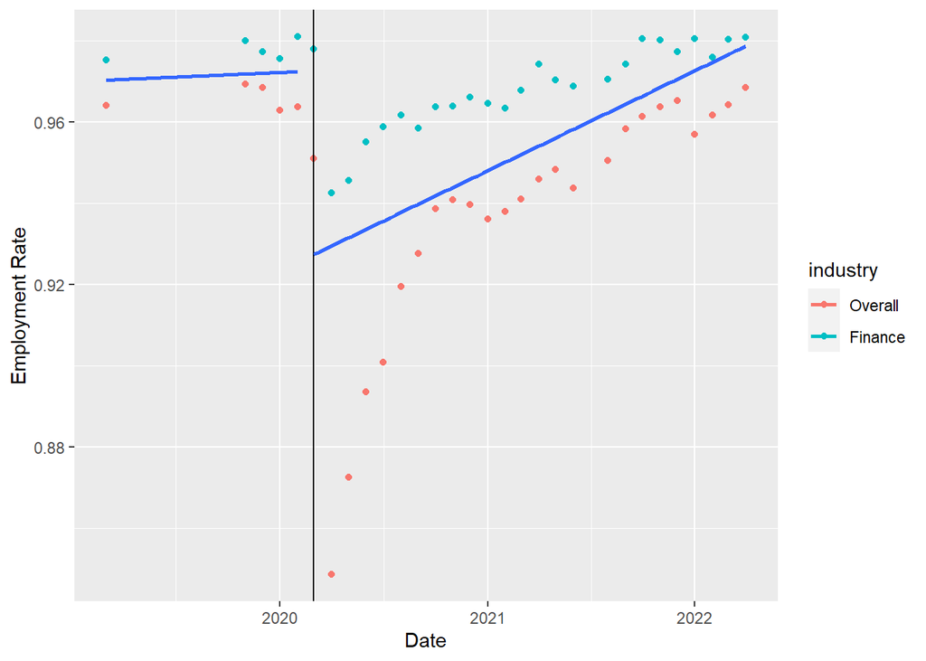

```r
# Extra: Let's see what the graph would look like if we had other industries like finance and transportation
finance <- full_join(cleandt, industry_codes)
finance$industry <- ifelse(finance$indname == 'Finance and Insurance, and Real Estate and Rental and Leasing', 1, 0)
financedt <- finance %>%
  group_by(industry, date) %>%
  summarize(emp_rate = 1 - mean(EMPSTAT %in% 20:22))
financedt <- financedt %>%
  drop_na(industry) %>%
  drop_na(date)
financedt <- financedt %>% mutate(industry= as.factor(industry))
financedt <- financedt %>% mutate(precovid = date < as.Date("2020-03-01"))
levels(financedt$industry) <- list("Overall" = "0",
                                          "Finance" = "1")

transport <- full_join(cleandt, industry_codes)
transport$industry <- ifelse(transport$indname == 'Transportation and Warehousing, and Utilities', 1, 0)
transportdt <- transport %>%
  group_by(industry, date) %>%
  summarize(emp_rate = 1 - mean(EMPSTAT %in% 20:22))
transportdt <- transportdt %>%
  drop_na(industry) %>%
  drop_na(date)
transportdt <- transportdt %>% mutate(industry= as.factor(industry))
transportdt <- transportdt %>% mutate(precovid = date < as.Date("2020-03-01"))
levels(transportdt$industry) <- list("Overall" = "0",
                                          "Transportation" = "1")

# Extra Visualizations of the other two markets finance and transportation at the effect of Covid
ggplot(financedt, aes(x = date, y = emp_rate, color = industry)) + geom_point() + labs(y = "Employment Rate", x = "Date") +
  geom_vline(xintercept = as.Date('2020-03-01')) + geom_smooth(aes(group = precovid), method = 'lm', se = FALSE)
```

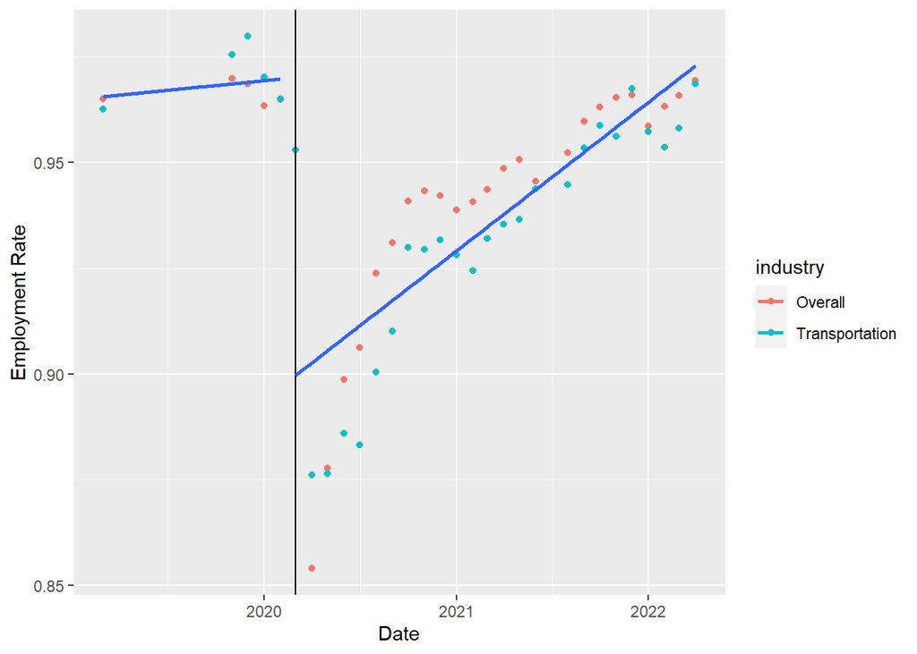

```r
ggplot(transportdt, aes(x = date, y = emp_rate, color = industry)) + geom_point() + labs(y = "Employment Rate", x = "Date") +
  geom_vline(xintercept = as.Date('2020-03-01')) + geom_smooth(aes(group = precovid), method = 'lm', se = FALSE)
```

## Conclusion

Overall, this suggests that COVID-19 had a hard impact on employment when the lockdowns happened, and people started getting laid off. However, after the vaccine was released and the economy started improving, we see that the employment rate just keeps on increasing no matter the industry as both retail and non-retail industry move in a similar direction. Although the biggest difference is that the employment rate reflected by the impact of COVID has had a higher impact on industries such as retail and transportation compared to those such as finanace and real estate management. This would mean that as of currently the people employed in the retail industry are behind in terms of economic power and monetary value due to lower employment rate compared to people employed in other industries.The difference in these effects may be attributable to the ease of going remote. It is much easier for someone working in finance to take a work computer home, where as retail and transportation workers need to be physically present at their place of work. The most well off consumers will most likely be white collar jobs which can easily be remotly done or have little office interaction.

While it seems obvious that COVID has had an impact on employment, where and why those impacts differ is the harder question to answer. The retail industry has had a rough time, seeing a 6% increase in unemployment post corona. To put this into perspective there are roughly 10 million cashier and salespersons jobs in the U.S. If 6% of those people lost their jobs, that would be over half a million workers left without a form of income.

From our analysis of the retail unemployment vs other industries, there was a swift recovery of employment in the overall labor force. This could be viewed positively as showing quick implementation of PPE protocols which allowed workers to return to their employment. But there is also a need to further analyze the changes in the labor forces overall. Workers could have chosen to leave th retail labor force, seeking better opportunities elsewhere or just retiring. This could create an effect were the unemployment rate drops due to a tighter labor market rather than more people being employed.